# Random Uncertainty

It has been previously discussed how systematic error is simply the difference between the true value and mean of all measured values. In practice, though, the true value is never known. If it were known, then there would be no need for an experiment. This systematic error leads to a systematic uncertainty that may be used to a particular degree of confidence the interval within the true value lies. These systematic uncertainties arise from instrument resolution, zero offsets, analog to digital conversions, etc. It has also been previously discussed how random error of a particular measurement is simply the difference between the specific measurement and the mean of all measured values. However, it has not been discussed how to determine the random uncertainty of a particular measurement or mean of a group of measurements. In the following text, the procedure to determine both of these quantities will be discussed.

## Random Uncertainty of a Single Measurement

We'll first begin with the random uncertainty of a single measurement. As it turns out, the random uncertainty of a single measurement is given by

$$ P_{x_i} = \pm t S_x $$

where $ t $ is the value found from the Student distribution, and $ S_x $ is the sample standard deviation. It may be asked then, "How is $ t $ and $ S_x $ found for a single measurement?" The answer is that it cannot. These quantities only apply to groups of measurements. A set of data must first be collected from a previous experiment to determine the random of a single measurement. This data set may then be used to calculate the Student $ t $ value and the sample standard deviation. If this set of data is large ( $ n \gt 30 $), then a $ t $ equal to $ 2 $ may be used; otherwise the particular $ t $ value would need to be found based on the degrees of freedom $ \nu $. This expression for a single measurement's random uncertainty is particularly useful when the measurement scenario is complicated or challenging to perform.

## Random Uncertainty of a Mean

The following expression may be used to determine the random uncertainty of a mean.

$$ P_{\bar x} = \pm t \frac{S_x}{\sqrt{n}} $$

where $ t $ is the value found from the Student distribution, $ S_x $ is the sample standard deviation, and $ n $ is the sample size. In this expression, the $ t $ value and sample standard deviation $ S_x $ may be determined for the particular data set for which the random uncertainty is being calculated or from another set of data from a previous experiment. The sample size $ n $ should always be from the data set for which the random uncertainty is being calculated. This expression is a more general form of the expression shown previously for a single measurement's random uncertainty. If the sample size is set to one (i.e., $ n = 1 $) as in the case for a single measurement, it may be seen that this expression becomes the previous expression for random uncertainty of a single measurement. Figure 1 depicts systematic uncertainty and random uncertainty, emphasizing the comparison of the random uncertainty of a single measurement and a mean.

Figure 1: Graphical Depiction of Uncertainty

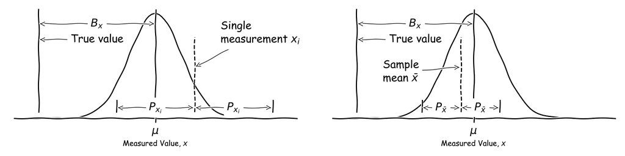

Shown on the left is a normal distribution centered at the population mean $ \mu $. The true value is indicated, and the systematic uncertainty $ B_x $ is depicted as the difference between the true value and the population mean $ \mu $. A single measurement $ x_i $ and it's associated random uncertainty $ P_{x_i} $ are also indicated on the diagram. Notice how the population mean $ \mu $ falls in the range of the single measurement $ x_i $'s random uncertainty value $ P_{x_i} $. This range is what is meant by the confidence interval. With a particular degree of confidence (say $ 95 \% $), the population mean $ \mu $ lies within the uncertainty range $ P_{x_i} $ of the single measurement $ x_i $. On the right is another normal distribution centered at the population mean $ \mu $. The true value and system uncertainty $ B_x $ are depicted similar to the diagram on the left. This time, however, the sample mean $ \bar x $ and it's associated random uncertainty $ P_{\bar x} $ are shown. Once again, the population mean $ \mu $ falls in range of the sample mean $ \bar x$'s random uncertainty $ P_{\bar x} $. This time, however, the range is smaller. This difference should be expected. All else being the same, the random uncertainty of a mean of measurements should always be smaller than the random uncertainty associated with a single measurement (i.e., $ P_{\bar x} \lt P_{x_i} $). If random uncertainty is the measure of how well a random variable is understood, then the more times the random variable is looked at (i.e., how many times data is collected), the less uncertain we should be of the random variable. The total uncertainty of the single measurement $ x_i $ is given by

$$ u_{x_i} = \sqrt{B_x^2 + P_{x_i}^2} $$

while the total uncertainty of the mean of measurements is given by

$$ u_{\bar x} = \sqrt{B_x^2 + P_{\bar x}^2} $$

## Example

**Given:**

In estimating the heating value of natural gas from a gas field, a series of samples are taken, and the heating value of each sample is measured by a calorimeter. The measured values of the heating value, in $ \frac{kJ}{kg} $, are shown below.

```python
data = [48530, 48980, 50210, 49860, 48560, 49540, 49270, 48850, 49320, 48680]
```

The manufacturer's specification of the calorimeter states that the device has an accuracy of

```python
a = 1.5
```

as a percent of the full range of

```python
R = [0, 100000]
```

in $ \frac{kJ}{kg} $.

**Required:**

Assuming the calorimeter itself does not introduce any random uncertainty into the measurement, calculate:

1. The random uncertainty for each measurement
2. The random uncertainty of the mean of the measurements
3. The random uncertainty of the mean of the measurements, assuming that $ S $ was calculated based on a large sample; but has the same value as computed in parts (a) and (b)

Estimate the total uncertainty of

4. The mean value of the measurement
5. A single measurement of the heating value of

```python
HV = 49500
```

in $ \frac{kJ}{kg} $ obtained later.

**Solution:**

Import any needed libraries

```python
import scipy.stats as sp
import statistics as stats
```

The mean of the data is

```python
xbar = stats.mean(data)
print(xbar)
```

```
49180
```

The sample standard deviation of the data is

```python
S_xbar = stats.stdev(data)
print(S_xbar)
```

```
566.313615509208
```

The number of data points in the sample is

```python
n = len(data)
print(n)
```

```
10
```

The degrees of freedom is then

```python
nu = n-1
print(nu)
```

```
9
```

A Student's t distribution may then be created.

```python
t_dist = sp.t(nu)
```

The $ t $ value for a $ 95 \% $ confidence interval is

```python
t = t_dist.ppf(1-(1-0.95)/2)
print(t)
```

```
2.2621571627409915
```

It should be noted that the $ 95 \% $ confidence interval should always be used unless otherwise stated. The random uncertainty for each measurement is then

```python
P_x = t * S_xbar / 1**0.5
print('The random uncertainty for each measurement is ', end='')
print(format(P_x, '.1f'), end='')
print(' kJ/kg.')    # ANSWER (a)
```

```
The random uncertainty for each measurement is 1281.1 kJ/kg.
```

The random uncertainty for the mean of the measurements is then

```python
P_xbar = t * S_xbar / n**0.5
print('The random uncertainty for the mean of the measurements is ', end='')
print(format(P_xbar, '.1f'), end='')
print(' kJ/kg.') # ANSWER (b)
```

```
The random uncertainty for the mean of the measurements is 405.1 kJ/kg.
```

The random uncertainty for the mean, assuming a large sample size with the same standard deviation, is then

```python
P_large = 2 * S_xbar / n**0.5
print('The random uncertainty for the mean, assuming a large sample ', end='')
print('size with the same standard deviation, is ', end='')
print(format(P_large, '.1f'), end='')
print(' kJ/kg.') # ANSWER (c)
```

```
The random uncertainty for the mean, assuming a large sample size with the same standard deviation, is 358.2 kJ/kg.
```

The systematic uncertainty due to the calorimeter is

```python
B_x = (a / 100) * (R[1] - R[0])
print(B_x)
```

```
1500.0
```

The total uncertainty in the mean value is then

```python
u_xbar = (B_x**2 + P_xbar**2)**0.5
print('The total uncertainty in the mean value is ', end='')
print(format(u_xbar, '.1f'), end='')
print(' kJ/kg.') # ANSWER (d)
```

```
The total uncertainty in the mean value is 1553.7 kJ/kg.
```

The percent uncertainty value could also be found.

```python
up_xbar = 100 * u_xbar / HV
print(up_xbar)
```

```
3.138876016277041
```

The total uncertainty in a single measurement is then

```python
u_x = (B_x**2 + P_x**2)**0.5
print('The total uncertainty in a single measurement is ', end='')
print(format(u_x, '.1f'), end='')
print(' kJ/kg.') # ANSWER (e)
```

```
The total uncertainty in a single measurement is 1972.6 kJ/kg.
```

The percent uncertainty value could also be found.

```python
up_x = 100 * u_x / HV
print(up_x)
```

```
3.9850719386754774
```

Download Complete Python Script Here